# LA County Covid-19

3/28/2020

## Introduction

- Human endeavors ahd human health
- Covid-19 lessons for sustainability in agriculture
- Do other zoonotic diseases follow patterns of Covid-19?

## Case Study – LA County

- By focusing in on one region, we can better appreciate both our response and the larger context.
- Disclaimer

Not peer reviewed work and well outside my typical professional work.

- Data Source

[Data hosted on github](https://github.com/CSSEGISandData/COVID-19), entitled Novel Coronavirus (COVID-19) Cases and provided by Johns Hopkins University, Center for Systems Science and Engineering.

## Work flow

- Combine Daily Situational Report into one dataframe
- Time consumig coding because of inconsisent source data formatting
- Subset Los Angeles County

## Early Records in Pandemic

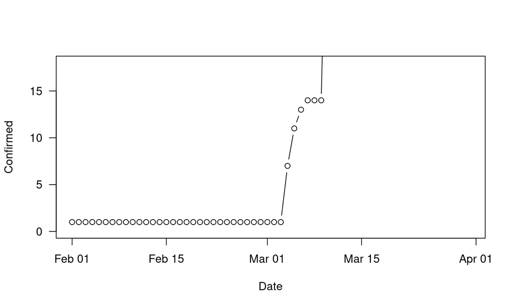

Early Records of Confirmed Cases of Covid-19 in LA County

## Dramatic Changes in March

- Note the missing data early in LA County

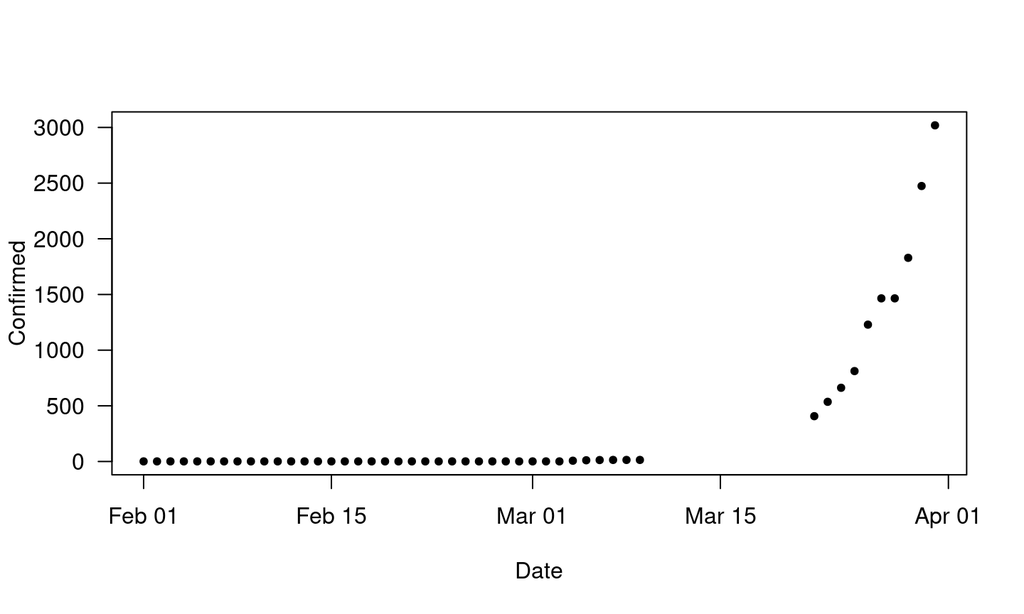

  Confirmed Cases in Los Angeles County (Source JHU-CSSE)

## Using LA County Public Health Data

I found press releases by the County to have some of the missing data:

- 3/09/2020 = 16 cases (github reported 14)
- 3/10/2020 = 17 cases, but missing LB and Pasadena
- 3/11/2020 = 27 cases
- 3/12/2020 = 32 cases
- 3/13/2020 = 40 cases
- 3/14/2020 = 53 cases
- 3/15/2020 = 69 cases
- 3/16/2020 = 94 cases
- 3/17/2020 = 144 cases
- 3/18/2020 = 190 cases
- 3/19/2020 = 231 cases
- 3/20/2020 = 292 cases
- 3/21/2020 = 351 cases
- 3/22/2020 = 409 cases (corrected as 407 on the 23rd, same as github)
- 3/23/2020 = 536 cases (90 hospitalized) same as github

## Complete Dataset

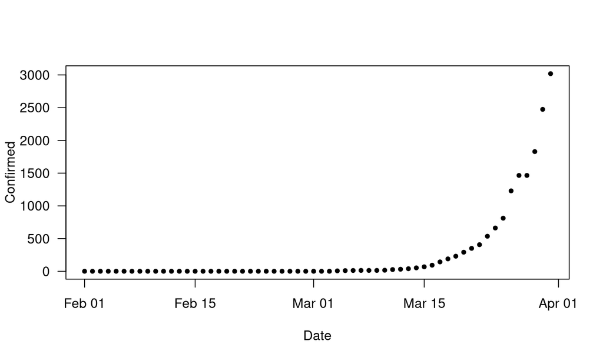

Confirmed Cases in Los Angeles County (Source JHU-CSSE and LA County Public Health)

## Determine Doubling Rate

- Doubling rate is an estimate of how time (days in our case) are the number of confirmed cases doubled
- An analysis is based on the slope of the natural log of the confirmed cases
- But when should we begin the analysis, i.e. when does the epidemic begin?

## Testing when the epidemic began?

- As it turns out the first 31 days there is only one confirmed infection – so, I’ll begin the analysis on the 32nd day, there were 7 infections.
- Using the r<sup>2</sup> to evaluate the models
  - Model 1: r<sup>2</sup> = 0.833
  - Model 2: r<sup>2</sup> = 0.991
- Doubling rate = log[2]/slope (growth rate)

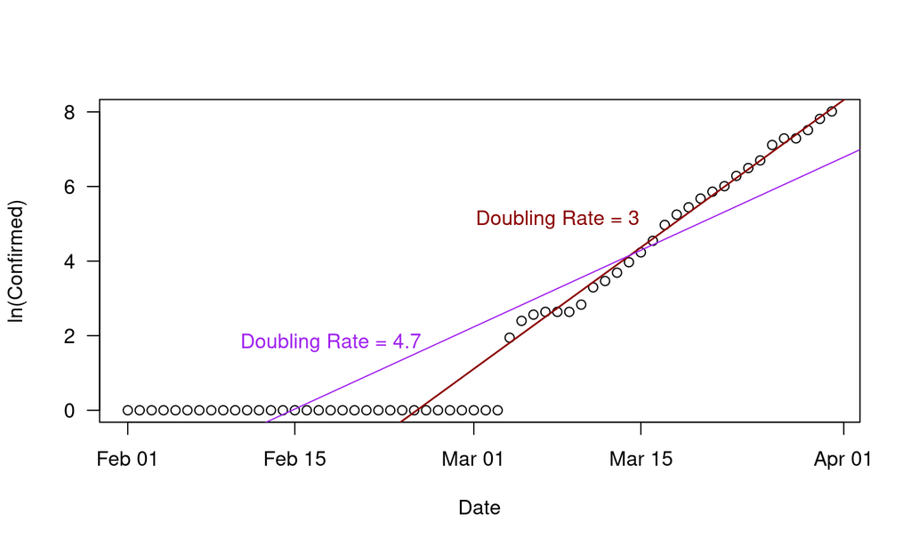

Confirm Cases in Los Angeles County and Estimated Doubling Rates

## Policy Lag Times

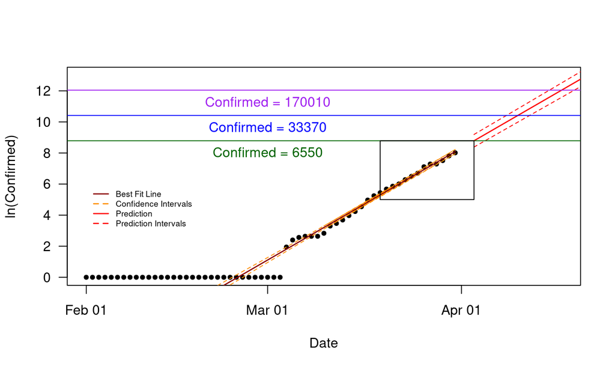

Predicted Number of Covid-19 Cases in Los Angeles

## April 3rd – Two Weeks of After Newsome Order

- County will have approximately 6550 confirmed cases.
- Predictions have changed with more data:
- March 25th 6170
- March 26th 6620
- March 27th 6810
- March 28th 7230
- March 29th 7190

## Changes in Doubling Rate

- Control of doubling rate is key to ‘flattening the curve’.
- Reducing contact between susceptables in the key for that process.
- SIR, SEIR, and SEIRS models used to explore various hypotheses

## Hospital and ICU Capacity

- California has 2.1 beds per 1,000 people
- With approximately 10.6 million residents, there are approximately 22260 beds in the county.
- Estimated 50% occupancy rate.
- Number of available beds = 11130
- assume about 20% of the confirmed cases need hospital beds

## Estimated date of hospital bed shortage

- Thus, LA County will run out of beds on 04/12.
- Model is missing is the category of ‘recovered’. After 20 days hospitalized patients will either be in recovery (and can go home) or have died. Thus, a worst case scenario.
- According to the LA Times, there are roughly 200 ICU beds in the county. I think about 5% of these who get sick need access to ICU. Probably an even more serious issue.

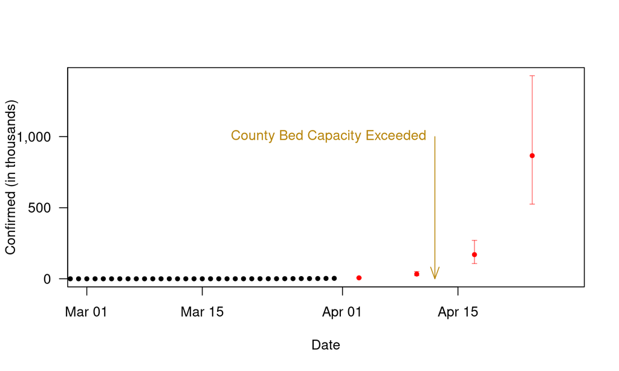

## Testing for an Nonlinear Growth Rate

With this simple analysis, I obtained the following results:

```
##         Date Confirmed logConfirmed      lwr      upr
## 1 2020-03-31      3019     8.012681 7.952206 8.226281
```

- Based on this, I suspect we are still well within the model expectations and there is no hint of flattening.